# Imbalance Study with Exogenous Variables on Feb-May 2019

Nilüfer Çetin - Spring 2020

01 03 2021

## Dataset

The first dataset consists of hourly imbalance statistics related to electricity consumption in Turkey between February and June 2019. Some columns can be listed as amount of positive imbalance, amount of negative imbalance, absolute imbalance and signed (total) imbalance.

```
##          Date Hour    Pos      Neg index Imbalance Absolute
## 1: 2019-02-01    0 741.95 -1280.87     1   -538.92   538.92
## 2: 2019-02-01    1 783.78 -1704.84     2   -921.06   921.06
## 3: 2019-02-01    2 792.26 -1128.54     3   -336.28   336.28
## 4: 2019-02-01    3 715.15 -1186.16     4   -471.01   471.01
## 5: 2019-02-01    4 686.83  -627.90     5     58.93    58.93
```

The second dataset includes hourly production series of electricity in the same period from some specified sources that are classified as renewable. Some columns can be listed as production amount in kWh from Sun Panels, Wind Turbines, Dams and Rivers.

```
##          Date Hour    Total     Dam   River    Wind  Sun index
## 1: 2019-02-01    0 31795.90 8394.19 3117.00 4190.21 0.17     1
## 2: 2019-02-01    1 29977.90 6363.66 2924.34 4293.61 0.00     2
## 3: 2019-02-01    2 28728.78 5810.97 2881.46 4165.15 0.00     3
## 4: 2019-02-01    3 27782.78 5318.83 2889.29 4051.20 0.00     4
## 5: 2019-02-01    4 27468.96 5200.48 2826.86 3852.96 0.00     5
```

## Statistical and Visual Analysis of Imbalance Series

Inspecting the data could be useful,

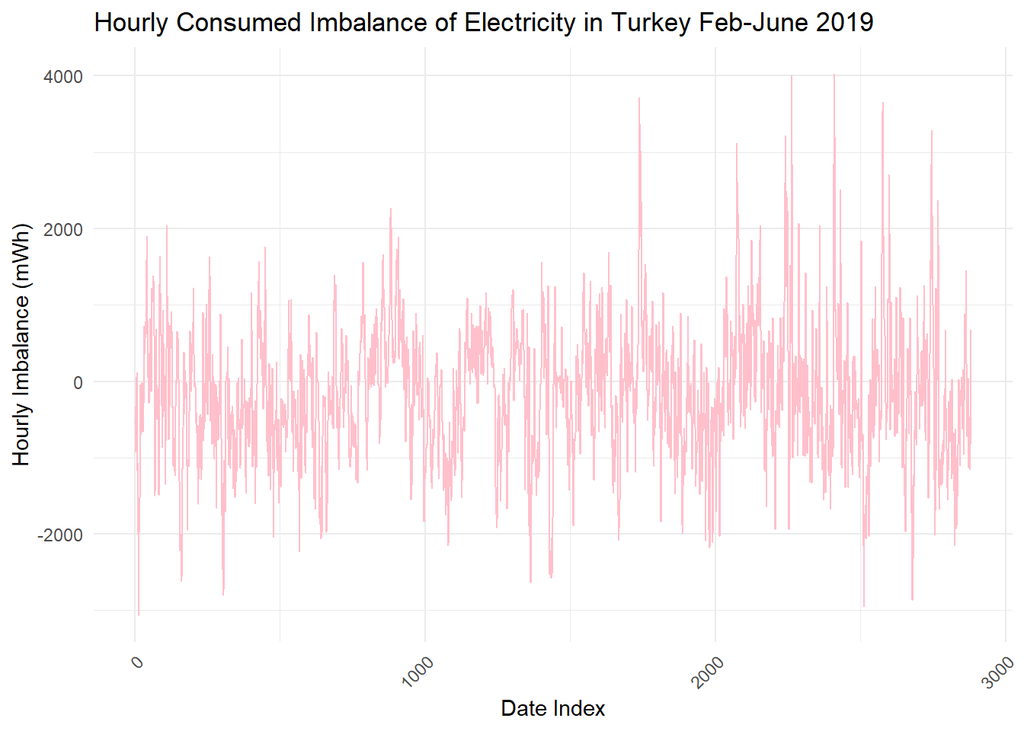

The data seems to be stationary, when checked with unit root test,

```
##
## #######################
## # KPSS Unit Root Test #
## #######################
##
## Test is of type: mu with 9 lags.
##
## Value of test-statistic is: 0.2883
##
## Critical value for a significance level of:
##                 10pct  5pct 2.5pct  1pct
## critical values 0.347 0.463  0.574 0.739
```

The null hypothesis that the data is stationary is failed to be rejected. Because of different consumption characteristics and production mixtures, the profiles of each hour might differ. Hence, visualizations on hourly series can be done,

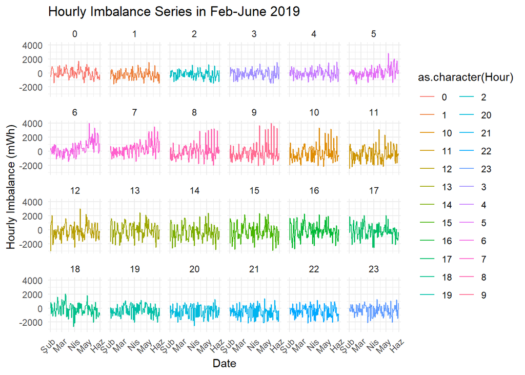

As can be seen, the series of hours with more industrial production seems to be less stationary. This assumption might be generalized by checking series from other seasons of the year.

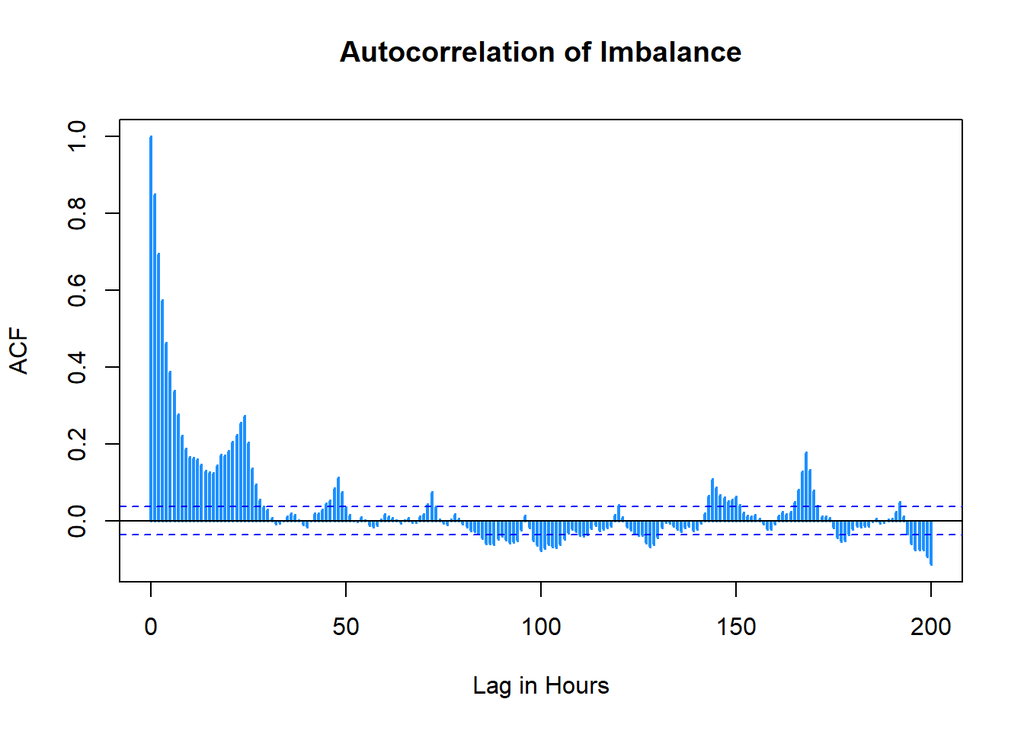

This auto-correlation function indicates daily and weekly seasonality. If hour-7 series are plotted,

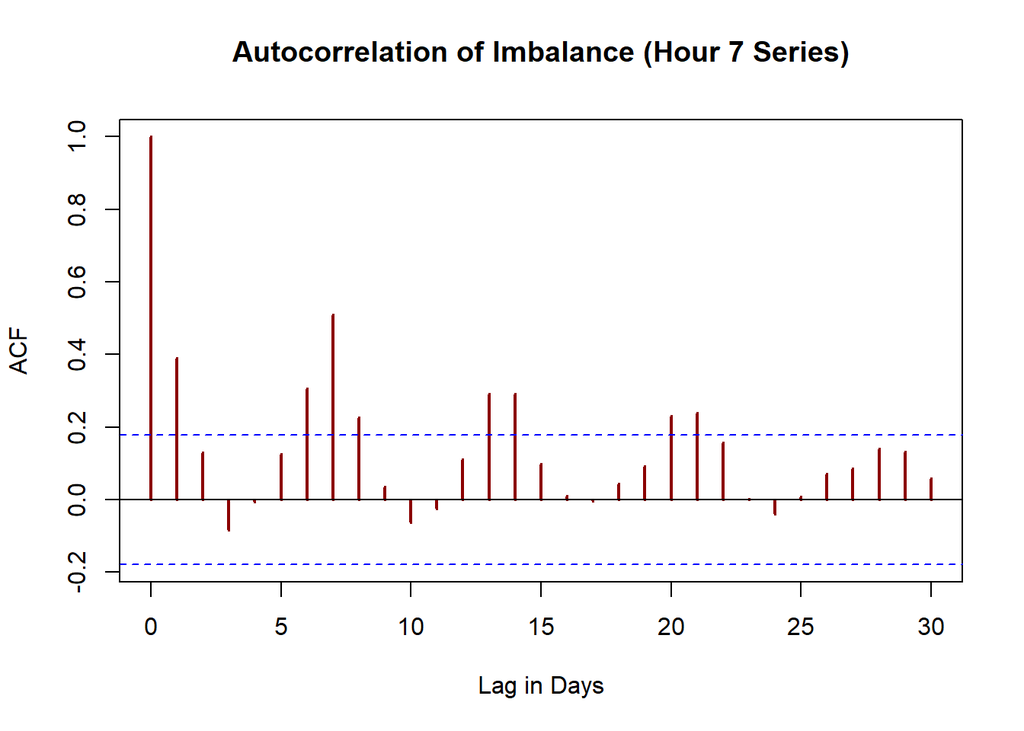

When correlations between imbalance statistics and production amounts from RES are observed,

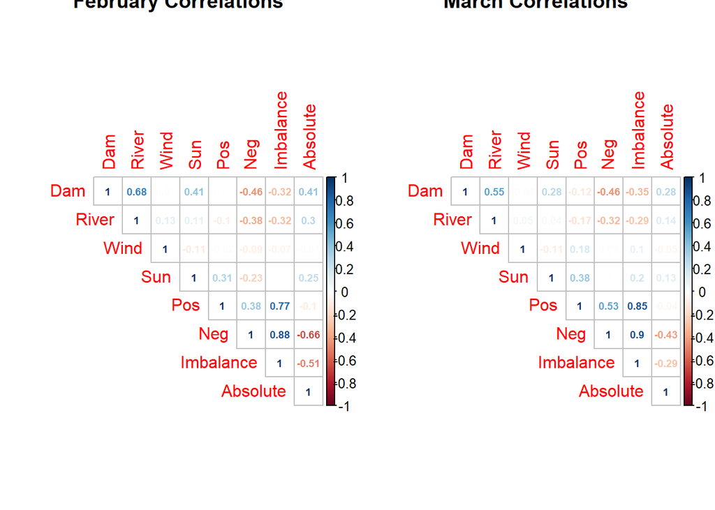

For April and May,

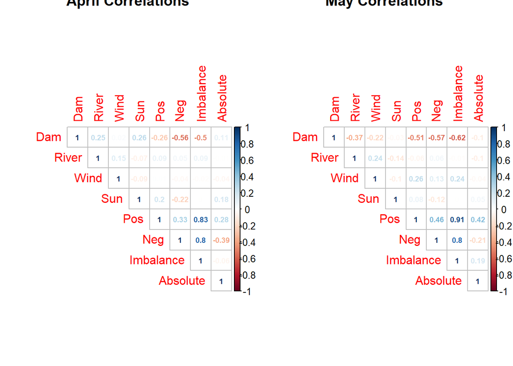

## Some Insights

1. Daily and weekly seasonality is existent in series.
2. Each hour has its own imbalance profile, characteristics, dynamics are different. Might affect the ARIMAX model parameter selections.
3. Productions or outages from RES have strong influence on the signed imbalance amount.
4. The main driver is the production from dams, at least in the season of target.
5. The weights of RES factors change through months.
6. The final models are not likely to be effectively tested on some other period since the drivers in summer or winter might be fundamentally different.

## Methodology

The data at hand will be used as a training data for now. To account for differences in hourly profiles, 24 different models of 24 different time windows will be constructed using ARIMAX models. Before delving into ARIMAX, an ARIMA model will be constructed for each series. By observing the relationship between residuals and production from RES, exogenous variables will be added by differentiating based on month and hour. At each step, the percentage of correctly guessed hours will be provided.

After some promising models have been found aws_weather data aggregated on hourly level will be used as exogenous variable to fit the model. At this point, because of the relationship between the weater data and the production from RES, the coefficients of ARIMAX and the training performances might be altered, probably diminished.

It is also possible to run linear regression to add these variables or run correlation tests with the pure imbalance amount to manually decide on the exogenous variables.

There are various models, the hour-14 for example,

```
## Series: binded[Hour == 14]$Imbalance
## ARIMA(2,0,2) with non-zero mean
##
## Coefficients:
##          ar1      ar2      ma1     ma2       mean
##       1.0598  -0.9102  -0.8847  0.8429  -341.5659
## s.e.  0.0919   0.0670   0.0954  0.1081    98.0153
##
## sigma^2 estimated as 945512:  log likelihood=-993.73
## AIC=1999.46   AICc=2000.2   BIC=2016.18
```

Whereas hour-22 series are,

```
## Series: binded[Hour == 22]$Imbalance
## ARIMA(0,0,0) with non-zero mean
##
## Coefficients:
##            mean
##       -461.3431
## s.e.    67.7393
##
## sigma^2 estimated as 555261:  log likelihood=-963.4
## AIC=1930.8   AICc=1930.91   BIC=1936.38
```

After the fit,

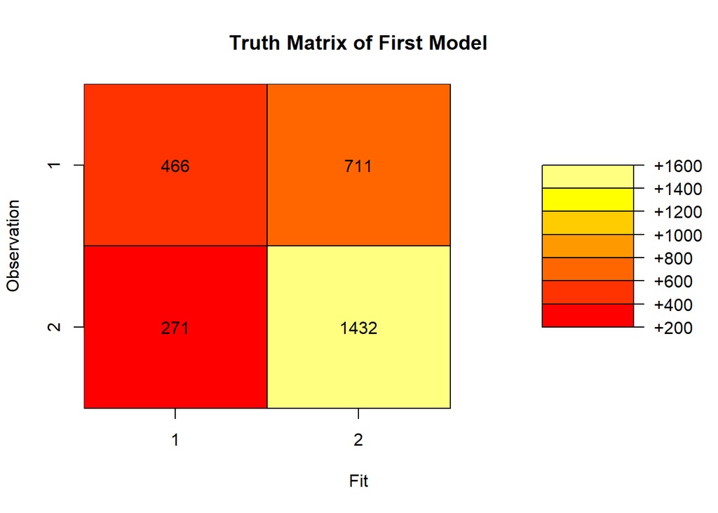

Negative imbalance is more frequent in the data, the model does not have much problem identifying or fitting this negative sign.

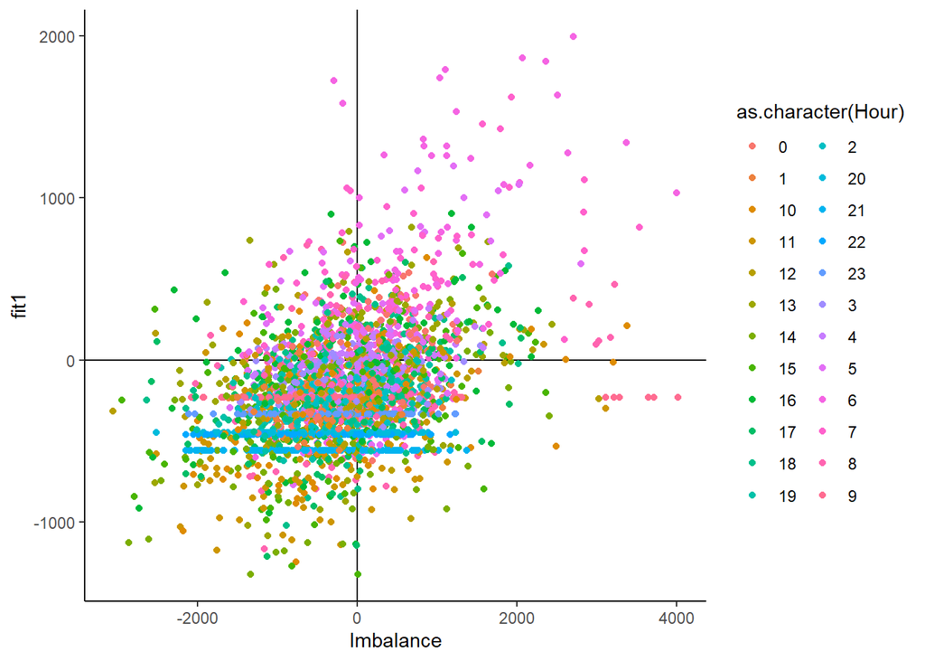

When hourly performances are checked,

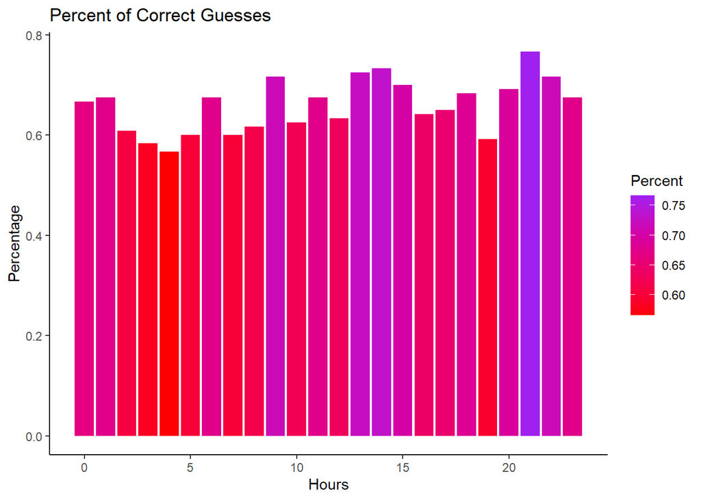

If correlations of residuals to productions from RES for each hour in each month is plotted,

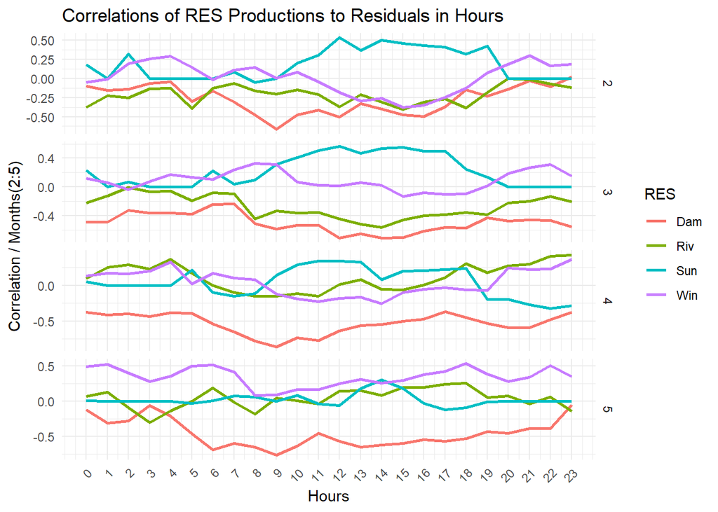

As it is seen, the main factors influencing the amount of imbalance change with hours and seasons.

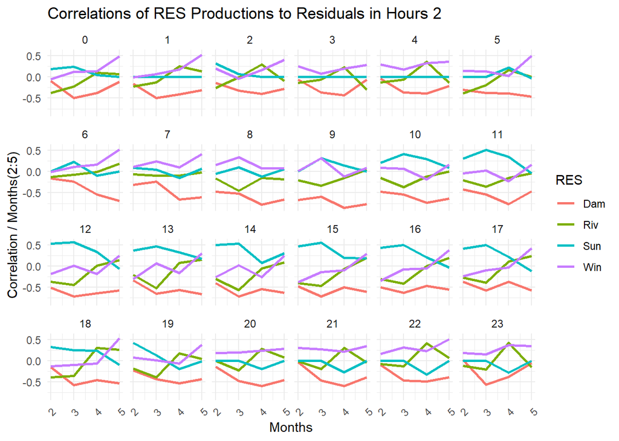

After that point adding the most prominent factor to each ARIMA model as exogenous variable seems to be useful. However, that may also change parameters of p, d and q. A list of added variables to each hours are,

```
##    Hours   Feb Mar Apr  May
## 1:   0:2 River Dam Dam Wind
## 2:   3:4    NA Dam Dam Wind
## 3:   5:6    NA Dam Dam  Dam
## 4:     7   Dam Dam Dam  Dam
## 5:  8:10   Dam Dam Dam Wind
## 6: 11:17   Dam Dam Dam  Dam
## 7: 18:22    NA Dam Dam  Dam
## 8:    23    NA Dam Dam Wind
```

Moving on with ARIMAX,

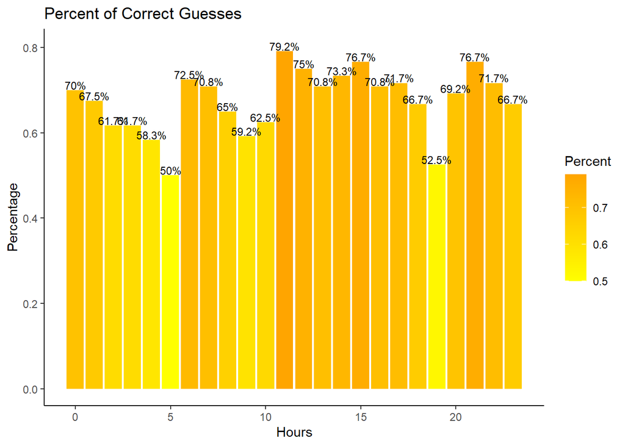

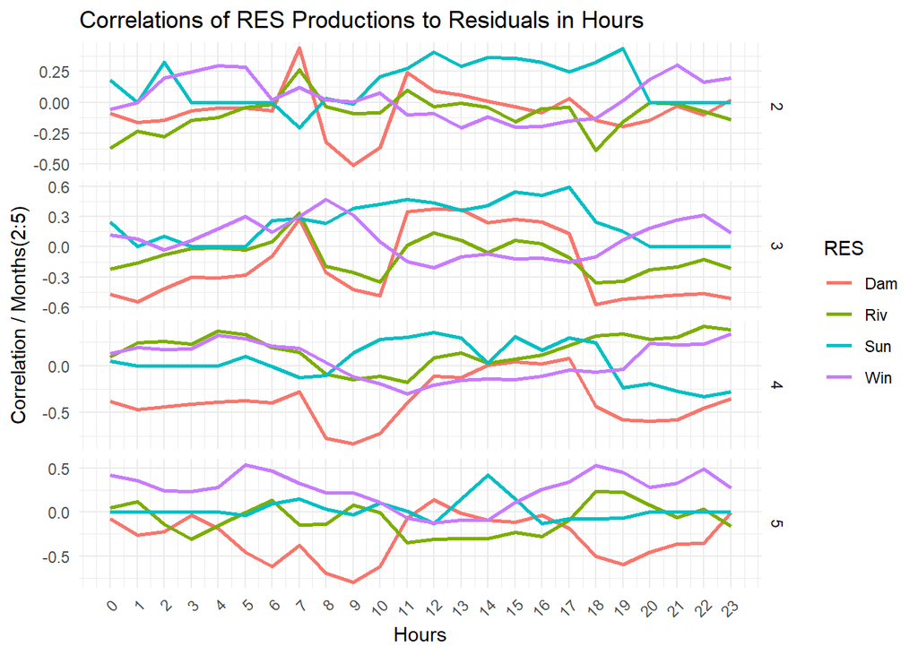

Some effects are still persistent in the models; if truth table is visualized,

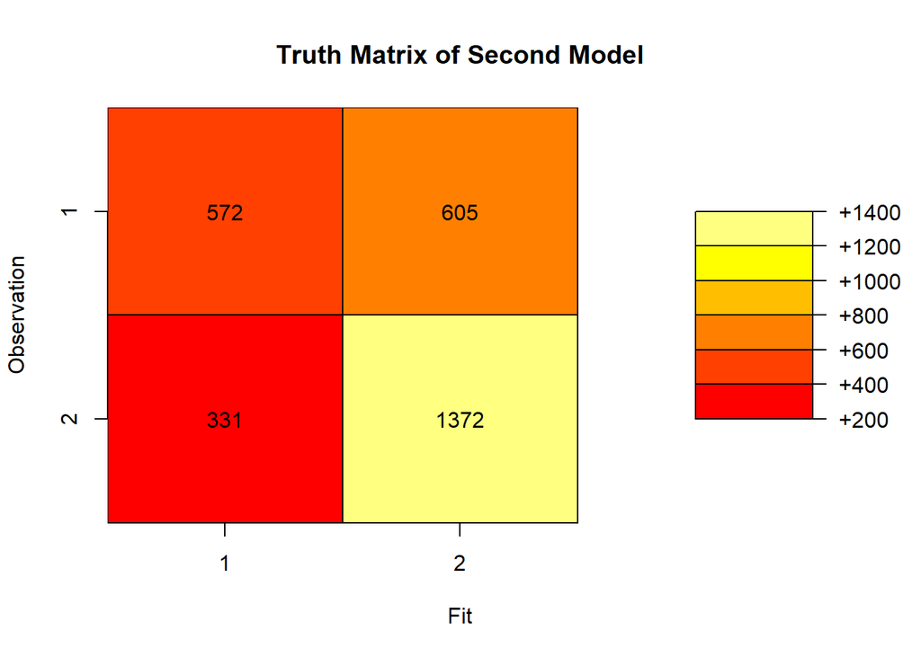

It is clear that the tendency to predict negative imbalance sign have decreased. This have increased the performance on positive signed hours. The overall train performance have been slightly increased from %65.9 to %67.5.

This have proven to be of little importance. Another model is developed by keeping p, d and q the same and adding exogenous variables. The truth matrix with %68.2 performance is,

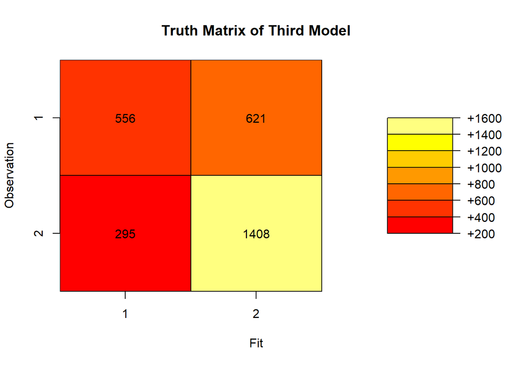

It is obvious that the performance have improved with respect to the first two models. However, there is still tendency to predict a negative imbalance sign. When hourly performances are compared,

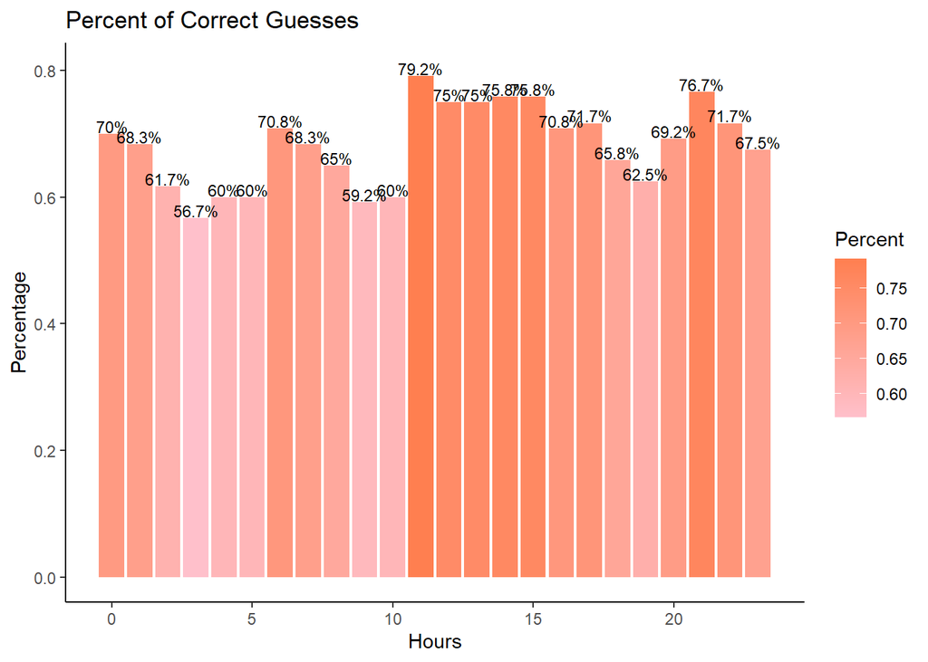

It is more relevant to use weather info to fit a model since in the prediction setting the amount of production from RES will not be known. From the previous research and analysis it is known that some factor are strongly correlated to some production amounts which can be listed as,

```
## [1] "DAMS: Humidity, SunSD Surface, Temperature Surface"
```

```
## [1] "RIVERS: PWAT Atmosphere, DLWRF Surface"
```

```
## [1] "WIND: VGRD-80, VGRD-10, Speed-80, GUST Surface"
```

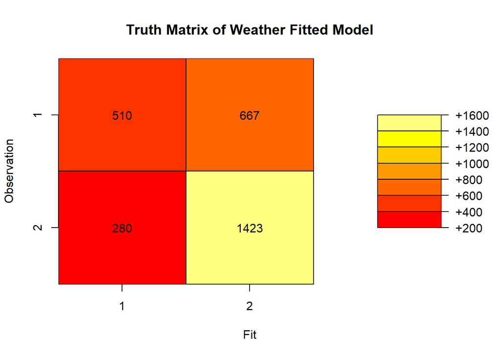

When this is checked, we observe that the model performance for the training set did not worsen much. It is actually %67.1.

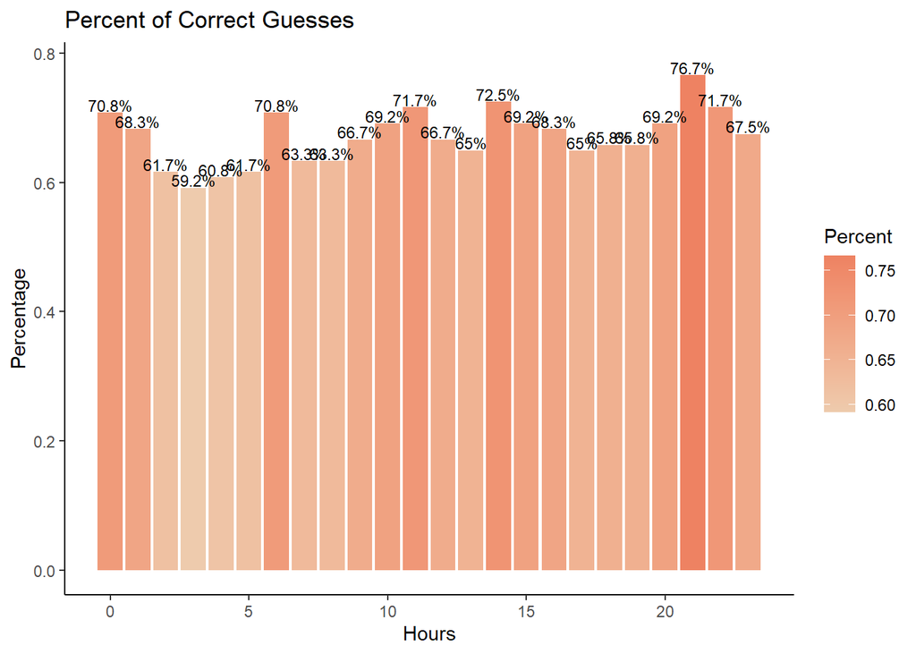

When the residuals series for each hour is checked,

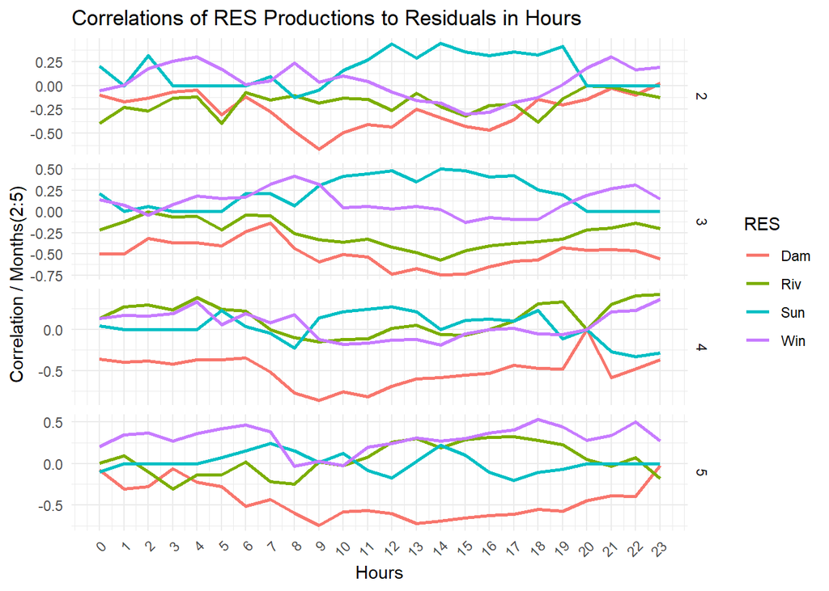

This actually shows that there is still info coming from RES production that is missed by the model. This might be result of,

1. The relationship is not linear; it might be squared, quadratic or cross product such as Dam.Wind etc.
2. The forecasts of weather data are not fully covering the production amount.

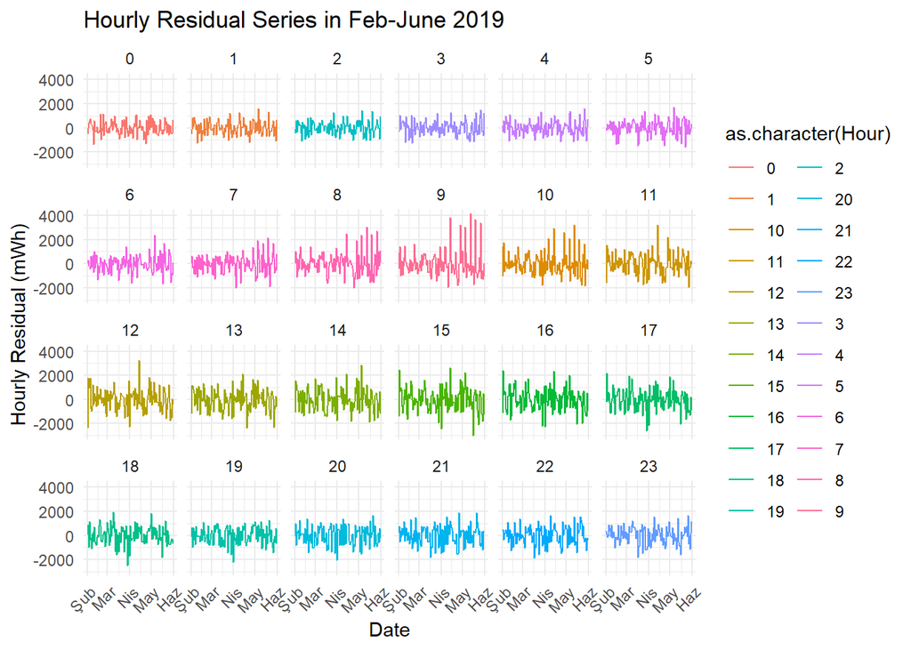

The volatility of in series for some hours seems to be still persistent in the data. This might be a natural dynamic or it might be related to the consumption side since most are between 7-15, hours in which the electricity consumption is also high.

## Some Challanges and Future Works

1. Using weather forecasts from 36-hours before to actually forecast a predictor.
2. Each hour in each season/month might have different behavior. We might be using 24 different models for 12 different months leading to 288 exogenous variable matrices to be constructed and analyzed.
3. The seasonal partitioning in the variables will lead to discrete and independent models that might perform poorly in season changes.
4. The system is dynamic and might be heavily dependent on the season testing can be complex because of the discreteness in the series and on accounted factors that might have been changed in a year.
5. Finding the actual drivers and their relations to the imbalance is actually complex requiring a lot of analysis and might not be logically understood, ie. why does dams affect the imbalance a lot in april? The models are bound to be data-based.

Some future recommendations can be,

1. To try devise a strategy to enter the market as an agent, eg. finding a threshold under and above which the forecasts might be less trustable.
2. To try incorporating the information coming from the unforeseen excesses or shortages in demand. (we are already good at predicting the demand how to see any unforeseen demand)
3. Running more detailed models which incorporate more weather data to model the production from RES as a whole. (this requires very detailed analysis, scatter plots, residual analysis etc., on BOTH weather-RES and RES-imbalance so the forecasts are somewhat indirect and unambigious)
4. Maybe to exclude the relationship between RES and include humidity, sunshine, vgrd, flux, temperature etc. directly.
5. First running regression models with some determined regressors; auto-correlation at lag 2, day of week, month+weather_variable etc. to see the good predictors for each hour in each month and construct the models using this result.